# Clase 10 - Guia evaluación de supuestos análisis paramétricos

OCE 386 - Introducción al análisis de datos con R.

Dr. José A. Gallardo.

Pontificia Universidad Católica de Valparaíso  
jose.gallardo@pucv.cl

10 October 2021

#### **Introducción**

Los principales supuestos de los análisis paramétricos son:

**Independencia**  
Cada observación de la muestra no debe estar relacionada con otra observación de la muestra.

**Homocedasticidad**  
En el caso de comparación de dos o más muestras éstas deben provenir de poblaciones con la misma varianza.

**Normalidad**  
Los datos de muestreo se obtienen de una población que tiene distribución normal.

**Regla de oro de los análisis paramétricos**  
Primero evalúe independencia, luego homogeneidad de varianzas y finalmente normalidad.

Esto porque la mayoría de las pruebas estadísticas paramétricas no toleran desvios de independencia, pero son bastante robustos a desviaciones de homogeneidad de varianzas o normalidad.

#### **Objetivos de aprendizaje**

Los objetivos de aprendizaje de esta guía son:

**1**. - Implementar métodos gráficos y análisis de residuos para evaluar supuestos de los análisis paramétricos.

**2**. - Implementar pruebas de hipótesis para evaluar supuestos de los análisis paramétricos.

**3**. - Elaborar un reporte dinámico en formato pdf con **[Rmarkdown](https://rmarkdown.rstudio.com/)**.

#### Librerías

| **Librería** | **Función** |
| --- | --- |
| **car** | Librería de acompañamiento al libro de J. Fox and S. Weisberg, An R Companion to Applied Regression, Third Edition, Sage, 2019. |
| **lmtest** | Librería que permite realizar análisis de diagnósticos de modelos lineales. |

#### **Comandos**

A continuación, se presentan algunos comandos que deberá usar para resolver los ejercicios de esta guía.

**1.-** Genera una gráfica de cuantiles teóricos de la distribución normal con relación a los cuantiles observados de los datos **qqnorm()**

**2.-** Genera una línea de regresión Y-X de cuantiles observados de los datos en función de los cuantiles teóricos con la distribución normal **qqline()**

**3.-** Función avanzada de gráficas qqplot de la librería car **qqPlot()**

**4.-** Ajusta modelos lineales con el formato de fórmula *(Variable Respuesta ~ Variable/s Explicativas)* **lm()**

**5.-** Realiza una prueba de normalidad de Shapiro-Wilk **shapiro.test()**

**6.-** Realiza una prueba de F para comparación de varianzas de dos muestras que provienen de poblaciones normales **vartest()**

**7.-** Prueba la hipótesis de homogeneidad de varianzas a través de 2 o más grupos, forma parte de la librería car **leveneTest()**

**8.-** Realiza una prueba de autocorrelación de Durbin-Watson **dwtest()**

### **Ejercicio 1.** Elaborar archivo Rmarkdown

Elabore y configure un archivo o file con extensión **.Rmd** y configúrelo para exportar el resultado como un documento dinámico **pdf**.

Utilice el siguiente ejemplo para completar la información de metadatos: Título: Reporte Evaluación de supuestos análisis paramétricos, nombre del autor: Su nombre.

Luego guarde inmediatamente su *script* como **script_10_nombre_apellido.Rmd**. Al finalizar la actividad deberá exportar y almacenar este script en su carpeta drive de tareas.

### **Ejercicio 2.** Configuración del reporte

En el primer bloque de códigos o **chunk** configure los comandos de la siguiente manera *knitr::opts_chunk$set(echo = TRUE)* y cargue las librerías **readxl**, **car**, **lmtest**, **dplyr**, **knitr** y **ggplot2**.

```r
knitr::opts_chunk$set(echo = TRUE)

library(readxl)
library(car)
library(lmtest)
library(dplyr)
library(knitr)
library(ggplot2)
```

Ejecute cada uno de los siguientes ejercicios en uno o más bloques de códigos diferentes. Sea ordenado y documente su reporte adecuadamente.

### **Ejercicio 3.** Estudio de caso peces epipelágicos

En el siguiente ejercicio se desea evaluar si los datos de peso de 3 especies de peces epipelágicos cumplen con los supuestos para realizar un análisis de varianza.

**a).** Importe el set de datos **peces.xlsx** y realice un análisis exploratorio de datos. Transforme la variable Especie en factor y la variable Peso en número, use las funciones as.factor() y as.numeric().

Incluya al menos un histograma y una gráfica de boxplot usando la librería ggplot2.

```r
Peces <- read_excel("peces.xlsx")
Peces$Especie <- as.factor(Peces$Especie)
Peces$Peso <- as.numeric(Peces$Peso)
head(Peces)
```

```
## # A tibble: 6 x 3
##   Muestra  Peso Especie
##     <dbl> <dbl> <fct>
## 1       1  4.17 Engraulis ringens
## 2       2  5.58 Engraulis ringens
## 3       3  5.18 Engraulis ringens
## 4       4  6.11 Engraulis ringens
## 5       5  4.5  Engraulis ringens
## 6       6  4.61 Engraulis ringens
```

```r
summary(Peces)
```

```
##     Muestra           Peso                        Especie
##  Min.   : 1.00   Min.   :3.590   Engraulis ringens    :10
##  1st Qu.: 8.25   1st Qu.:4.550   Galaxias maculatus   :10
##  Median :15.50   Median :5.155   Strangomera bentincki:10
##  Mean   :15.50   Mean   :5.073
##  3rd Qu.:22.75   3rd Qu.:5.530
##  Max.   :30.00   Max.   :6.310
```

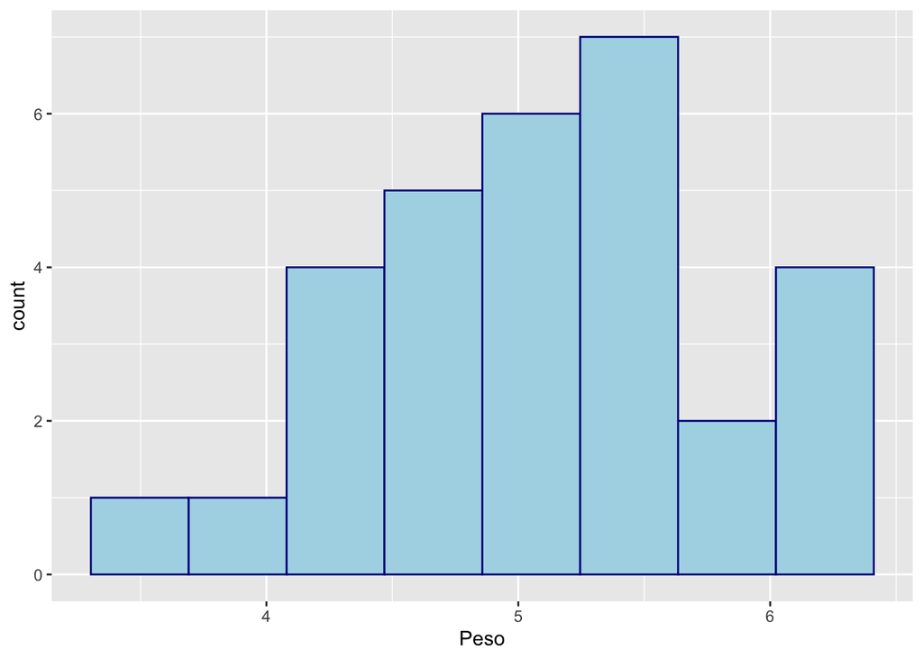

```r
p <-  ggplot(Peces, aes(x=Peso))
p + geom_histogram(color="darkblue", fill="lightblue", bins = 8)
```

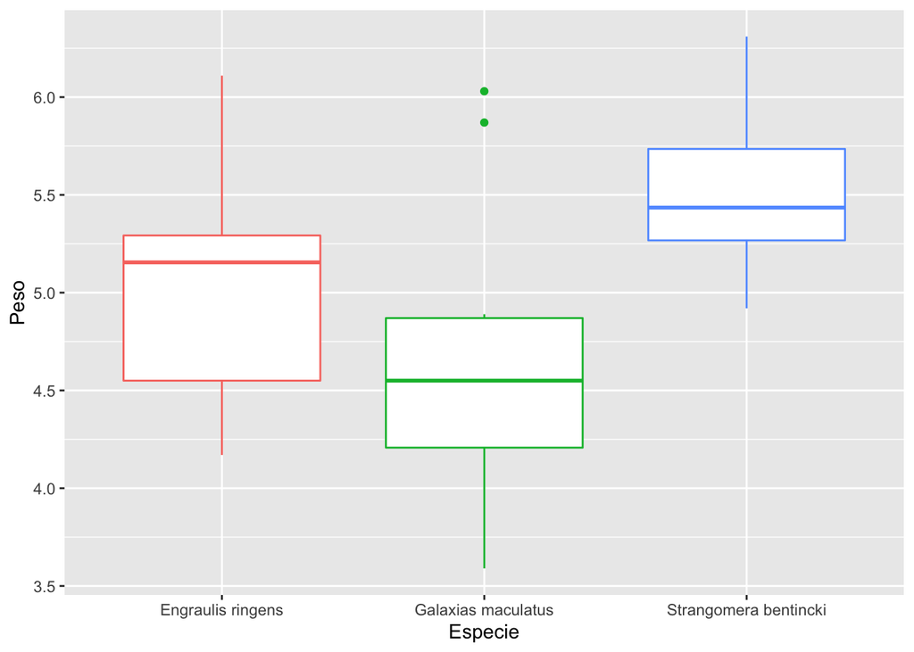

```r
q <-ggplot(Peces, aes(x=Especie, y=Peso, color=Especie)) +
  geom_boxplot()+theme(legend.position="none")
q
```

**b).** Elabore un modelo lineal del análisis de varianza para este experimento donde peso en la variable de interes en función de las especies.

Modelo lineal

```r
lm.aov <- lm(Peso ~ Especie, data = Peces)
anova(lm.aov)
```

```
## Analysis of Variance Table
##
## Response: Peso
##           Df  Sum Sq Mean Sq F value  Pr(>F)
## Especie    2  3.7663  1.8832  4.8461 0.01591 *
## Residuals 27 10.4921  0.3886
## ---
## Signif. codes:  0 '***' 0.001 '**' 0.01 '*' 0.05 '.' 0.1 ' ' 1
```

**c).** Realice una evaluación de supuestos mediante métodos basados en análisis de residuales y pruebas de hipótesis.

Independencia

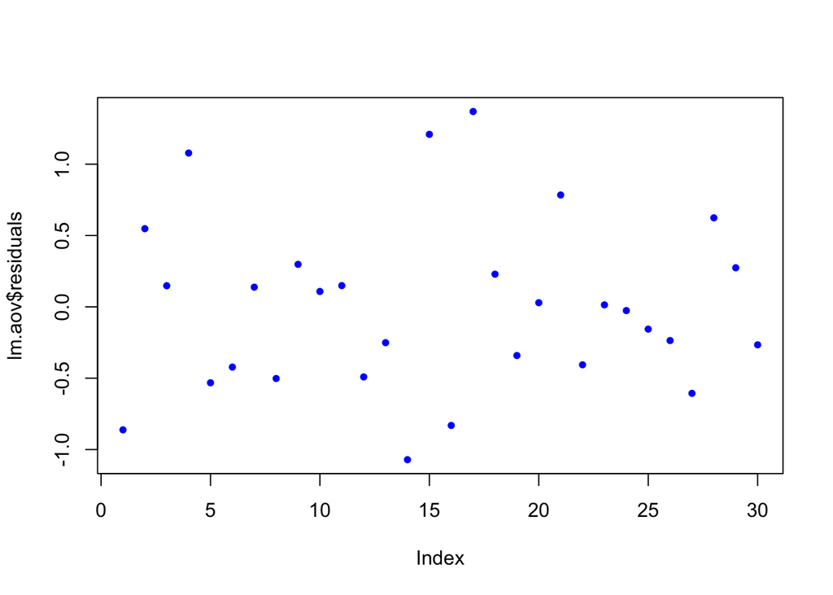

```r
plot(lm.aov$residuals, pch=20, col = "blue")
```

```r
dwtest(Peso ~ Especie, data = Peces,
       alternative = c("two.sided"),
       iterations = 15)
```

```
##
##  Durbin-Watson test
##
## data:  Peso ~ Especie
## DW = 2.704, p-value = 0.09963
## alternative hypothesis: true autocorrelation is not 0
```

Homogeneidad de varianzas

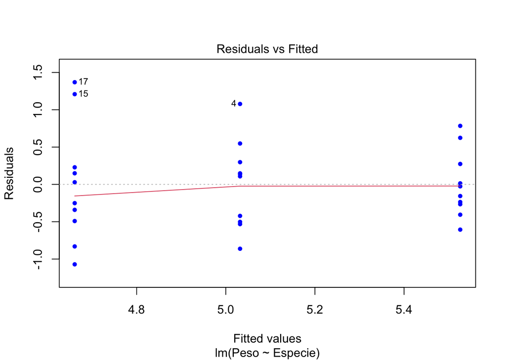

```r
plot(lm.aov, 1, pch=20, col = "blue")
```

```r
leveneTest(Peso ~ Especie, data = Peces,
           center = "median")
```

```
## Levene's Test for Homogeneity of Variance (center = "median")
##       Df F value Pr(>F)
## group  2  1.1192 0.3412
##       27
```

Normalidad

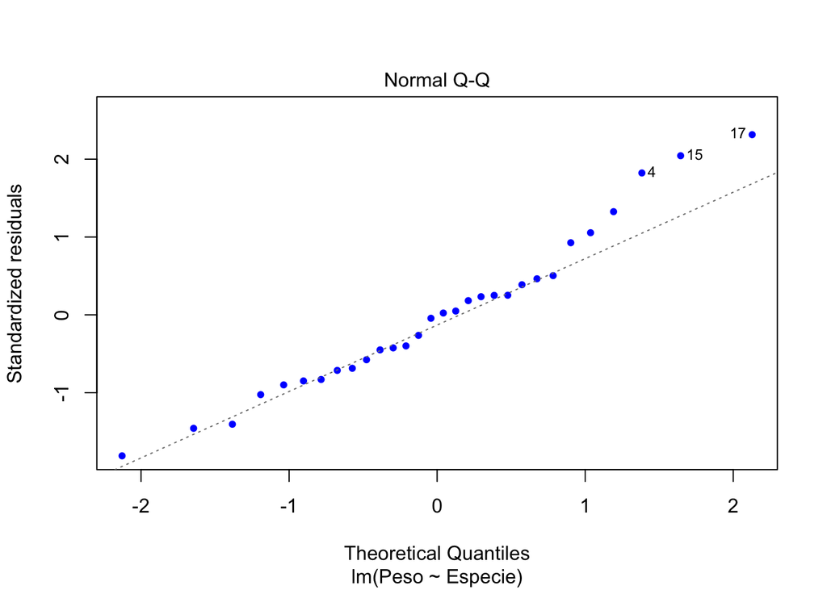

```r
plot(lm.aov, 2, pch=20, col = "blue")
```

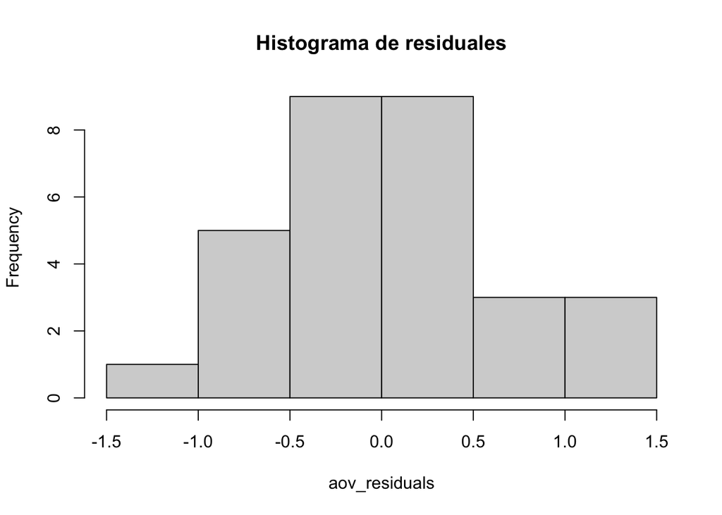

```r
aov_residuals <- residuals(object = lm.aov)
hist(x= aov_residuals, main = "Histograma de residuales")
```

```r
shapiro.test(x= aov_residuals)
```

```
##
##  Shapiro-Wilk normality test
##
## data:  aov_residuals
## W = 0.96607, p-value = 0.4379
```

**d).** Interprete sus resultados y concluya si es posible hacer o no un análisis de varianza para este experimento.

```r
#Se realizaron los gráficos y las pruebas para cada uno de los supuestos. Los resultados de las pruebas mostraron que se cumplían los tres supuestos (independencia, homogeneidad de varianzas y normalidad); ya que éstas pruebas presentaron p-valores superiores al nivel de significación del 5%. Debido al cumplimiento de los tres supuestos, se concluye que para este experimento es posible realizar el análisis de varianza.

# Del análisis de varianza es posible concluir que hay diferencias significativas de peso entre las especies.
```